# Lab 2 Avocados

Rachel Loh

1-24-20

```r
library(tidyverse)
```

```r
avocado <- read_csv("./avocado.csv")
```

This dataset contains information on avocados and specifically looks at the pricing, region, and various other elements. Therefore, this data is useful for analyzing prices in relationship to other factors. All the information in the data set comes from the retail sales of Hass avocados.

```r
unique_avocado <- unique(avocado$region)
sort(unique_avocado)
```

```
##  [1] "Albany"              "Atlanta"             "BaltimoreWashington"
##  [4] "Boise"               "Boston"              "BuffaloRochester"
##  [7] "California"          "Charlotte"           "Chicago"
## [10] "CincinnatiDayton"    "Columbus"            "DallasFtWorth"
## [13] "Denver"              "Detroit"             "GrandRapids"
## [16] "GreatLakes"          "HarrisburgScranton"  "HartfordSpringfield"
## [19] "Houston"             "Indianapolis"        "Jacksonville"
## [22] "LasVegas"            "LosAngeles"          "Louisville"
## [25] "MiamiFtLauderdale"   "Midsouth"            "Nashville"
## [28] "NewOrleansMobile"    "NewYork"             "Northeast"
## [31] "NorthernNewEngland"  "Orlando"             "Philadelphia"
## [34] "PhoenixTucson"       "Pittsburgh"          "Plains"
## [37] "Portland"            "RaleighGreensboro"   "RichmondNorfolk"
## [40] "Roanoke"             "Sacramento"          "SanDiego"
## [43] "SanFrancisco"        "Seattle"             "SouthCarolina"
## [46] "SouthCentral"        "Southeast"           "Spokane"
## [49] "StLouis"             "Syracuse"            "Tampa"
## [52] "TotalUS"             "West"                "WestTexNewMexico"
```

```r
clean_avocado <- avocado %>%
  mutate(region = factor(region)) %>%
  filter(region %in% c("Plains" , "Midsouth" , "West" , "SouthCentral" , "Southeast" , "Northeast" , "GreatLakes" , "SouthWest" , "WestTexNewMexico", "NorthernNewEngland"))
clean_avocado
```

```
## # A tibble: 1,064 x 14
##       X1 Date       AveragePrice `Total Volume` `4046` `4225` `4770`
##    <dbl> <date>            <dbl>          <dbl>  <dbl>  <dbl>  <dbl>
##  1    43 2015-03-01         1.09       1619341. 8.54e5 4.61e5 1.14e4
##  2    19 2015-08-16         1.88         32159. 5.37e3 1.55e4 3.56e1
##  3    32 2016-05-15         1.65         47778. 5.53e3 2.36e4 2.75e3
##  4     0 2015-12-27         1.05       2065131. 4.35e5 1.02e6 1.04e5
##  5     0 2015-12-27         1.46        142710. 2.99e4 4.84e4 3.86e1
##  6    22 2016-07-24         1.75        103129. 3.83e3 5.47e4 5.02e3
##  7    26 2016-06-26         1.03       2101836. 1.04e6 4.91e5 9.37e3
##  8    47 2015-02-01         1.67         30193. 3.90e3 1.45e4 3.22e1
##  9    48 2017-01-29         1.08        121204. 3.52e4 5.41e3 0.
## 10    13 2016-09-25         1.58        315399. 2.32e4 2.36e5 3.71e3
## # … with 1,054 more rows, and 7 more variables: `Total Bags` <dbl>, `Small
## #   Bags` <dbl>, `Large Bags` <dbl>, `XLarge Bags` <dbl>, type <chr>,
## #   year <dbl>, region <fct>
```

1. Which major region sold the most organic small Hass avocados in 2017? From this data, we can see that the Northeast region sold the most organic Hass avocados.

```r
colnames(clean_avocado)[5] <- "small_avocado"
clean_avocado %>%
  select(region, type, year, small_avocado)%>%
  filter(year == 2017, type == "organic")%>%
  arrange(desc(small_avocado))
```

```
## # A tibble: 166 x 4
##    region       type     year small_avocado
##    <fct>        <chr>   <dbl>         <dbl>
##  1 Northeast    organic  2017       127052.
##  2 West         organic  2017        72450.
##  3 West         organic  2017        52928.
##  4 West         organic  2017        46575.
##  5 Northeast    organic  2017        45273.
##  6 West         organic  2017        43817.
##  7 West         organic  2017        43228.
##  8 West         organic  2017        42642.
##  9 SouthCentral organic  2017        41198.
## 10 West         organic  2017        38226.
## # … with 156 more rows
```

2. Use separate() to split the Date variable into year, month, and day. In which month is the highest volume of avocado sales? From this data, we can see that February had the highest volume of avocado sales.

```r
colnames(clean_avocado)[6] <- "total_vol"
clean_avocado %>%
  separate(col = Date, into = c("Year", "Month", "Day"), sep = "-") %>%
  arrange(desc(total_vol))
```

```
## # A tibble: 1,064 x 16
##       X1 Year  Month Day   AveragePrice `Total Volume` small_avocado total_vol
##    <dbl> <chr> <chr> <chr>        <dbl>          <dbl>         <dbl>     <dbl>
##  1     7 2018  02    04            1.22       7508650.       480604.  5402444.
##  2    10 2015  10    18            0.99       4866607.        93569.  4025382.
##  3     6 2018  02    11            1.24       5694136.       565852.  3782154.
##  4     8 2018  01    28            1.23       5680958.       418911.  3730288.
##  5    32 2016  05    15            1.13       4999101.       100735.  3556590.
##  6    30 2016  05    29            1.14       5141315.       141465.  3554079.
##  7     3 2018  03    04            1.22       5318555.       364721.  3542626.
##  8    47 2016  01    31            1.06       4650798.       102907.  3443651.
##  9    49 2017  01    22            1.39       5007356.       206779.  3425748.
## 10    29 2015  06    07            1.27       4721927.       109588.  3416600.
## # … with 1,054 more rows, and 8 more variables: `4770` <dbl>, `Total
## #   Bags` <dbl>, `Small Bags` <dbl>, `Large Bags` <dbl>, `XLarge Bags` <dbl>,
## #   type <chr>, year <dbl>, region <fct>
```

3. Which metro area regions sold the most total avocados? Plot side-by-side boxplots of Total Volume for only the 5 regions with the highest averages for the Total Volume variable.

Los Angeles sold the most total avocados.

```r
different_clean_avocado <- avocado %>%
  mutate(region = factor(region)) %>%
  filter(!region%in% c("Plains" , "Midsouth" , "West" , "SouthCentral" , "Southeast" , "Northeast" , "GreatLakes" , "SouthWest" , "WestTexNewMexico", "NorthernNewEngland", "TotalUS", "California", "NewYork"))
colnames(different_clean_avocado)[4] <- "total_vol"

different_clean_avocado %>%
  group_by(region) %>%
  summarise(sum_total_vol = sum(total_vol)) %>%
  arrange(desc(sum_total_vol)) %>%
  top_n(5)
```

```
## # A tibble: 5 x 2
##   region              sum_total_vol
##   <fct>                       <dbl>
## 1 LosAngeles             138052320.
## 2 PhoenixTucson           68691354.
## 3 DallasFtWorth           62595467.
## 4 Houston                 59805984.
## 5 BaltimoreWashington     48647013.
```

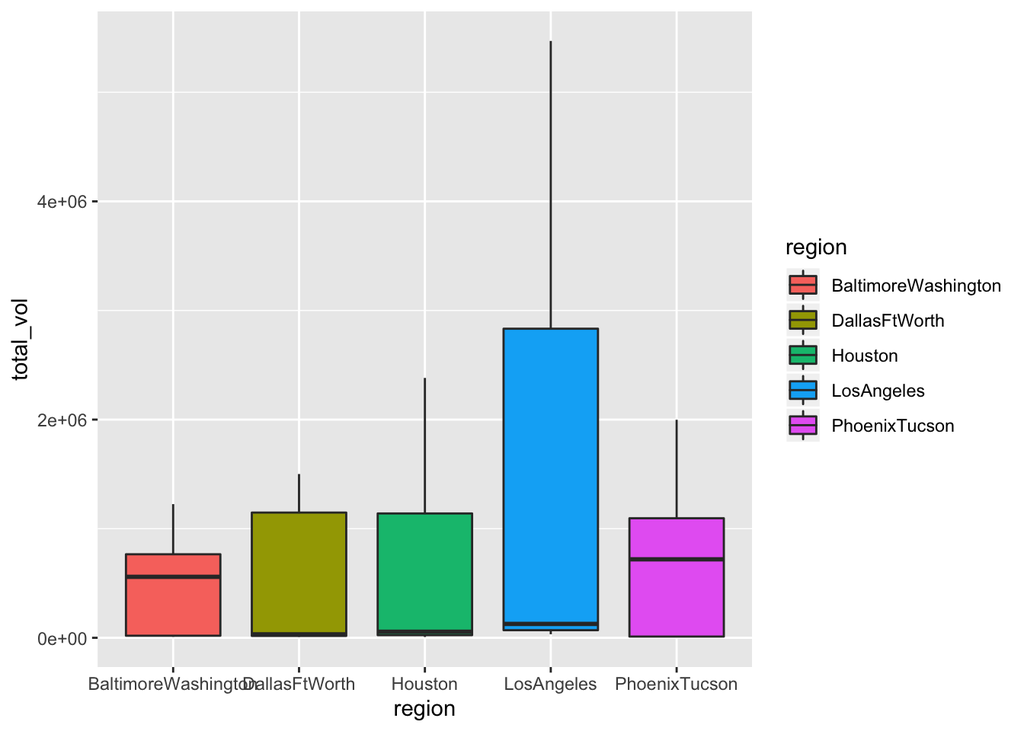

```r
colnames(avocado)[4] <- "total_vol"

avocado %>%
  filter(region%in% c("LosAngeles", "PhoenixTucson", "DallasFtWorth", "Houston", "BaltimoreWashington")) %>%
  ggplot() + geom_boxplot(mapping = aes(x = region, y = total_vol, fill = region))
```

RESHAPING In which regions is the price of organic versus conventional avocados most different? Support your answer with a few summary numbers and a plot.

From this plot we can see that San Francisco is has the greatest difference in organic and conventional.

```r
reavocado <- avocado %>%
  mutate(region = factor(region)) %>%
  filter(region %in% c("LosAngeles", "SanDiego", "Sacramento", "SanFrancisco")) %>%
  select(AveragePrice, region, type)%>%
  group_by(type, region)%>%
  summarise(meanprice = mean(AveragePrice))%>%
  pivot_wider(names_from = type, values_from = meanprice) %>%
  mutate(subtract = organic - conventional)
reavocado
```

```
## # A tibble: 4 x 4
##   region       conventional organic subtract
##   <fct>               <dbl>   <dbl>    <dbl>
## 1 LosAngeles          0.960    1.46    0.502
## 2 Sacramento          1.28     1.97    0.688
## 3 SanDiego            1.04     1.72    0.685
## 4 SanFrancisco        1.39     2.25    0.850
```

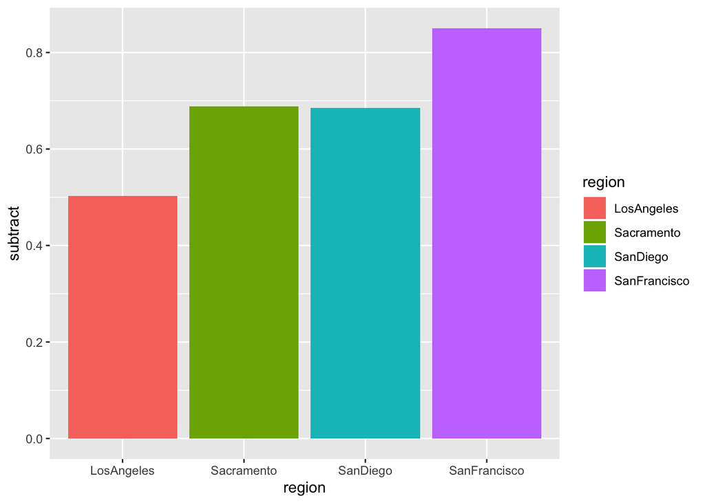

```r
reavocado %>%
  ggplot() + geom_col(mapping = aes(x = region, y = subtract, fill = region))
```

2. The following plot shows, for all 4 California regions, the percent of Hass avocado sales that are small, large, or extra large; conventional vs. organic. Recreate the plot.

This code creates the plot based on all 4 regions, percentages, and size.

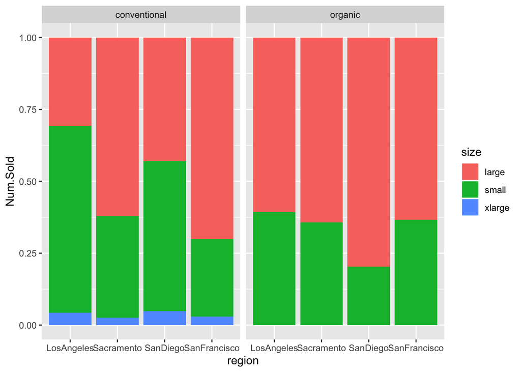

```r
colnames(avocado)[5] <- "small"
colnames(avocado)[6] <- "large"
colnames(avocado)[7] <- "xlarge"
avocado %>%
  mutate(region = factor(region), type = factor(type)) %>%
  filter(region %in% c("LosAngeles", "SanDiego", "Sacramento", "SanFrancisco")) %>%
  select(small, large, xlarge, region, type) %>%
  pivot_longer(cols = small:xlarge, names_to = "size", values_to = "Num.Sold") %>%
  ggplot() + geom_col(mapping = aes(x = region, y = Num.Sold, fill = size), position = "fill") + facet_wrap(~type)
```